# Oregon LiDAR CHM Mapping Project

Gavin Adams - Adams Geospatial

# Packages

Like any R project, the first step is to load in the packages that are required for this project. The one thing of note is the last line loads in the CHM downloading function. As described in the comments in the cell, the path to the CHM script must be included for R to pull the functions in.

```r
library(dplyr)
library(terra)
library(sf)
library(ForestTools)

library(whitebox) # This package is worth looking in to.
source("oregon_chm_downloader.r") # The file "oregon_chm_downlodader.r" needs to be in the same folder as the .RMD otherwise a path to the file needs to be specified
#TODO turn the CHM downloaded in to a R package
```

# Filter the Veg Shapefiles

This next block of code sets the filters for the shape file. Then reads in the vegetation shape file. (you may need to update paths to the shapefile if you try to run the script)

```r
year_filter <- 1946
size_filter <- 9

veg_shapefiles <- st_read("Veg_ShapeFiles/2003-Veg_Siuslaw/veg.shp", quiet = T)
filtered_veg <- veg_shapefiles %>% filter(YR_ORIG > year_filter & L1_SZCL >size_filter)
```

# Downloading the First AOI CHM Raster

Here is the test of the first AOI based on the filtered vegetation shapefiles. The AOI is then fed in to the downloader function. When the mask parameter is set to true the output raster will be masked to the shapefile. There is also a parameter that allows for the definition of the output path of the raster. I am going to go in and add an parameter to not save a copy of the raster locally when its downloaded.

```r
source("oregon_chm_downloader.r")
aoi <- filtered_veg[1,]
chm<- download_oregon_chm(aoi, mask = TRUE) #TODO add an option to not save the downloaded raster
```

```
## Original CRS: NAD_1983_Albers
```

```
## Transformed bounds: 7322179.83772722, 614584.885749461, 7323133.20740666, 615205.483304483
```

```
## Total area: 317x206 pixels
```

```
## Breaking into 1x1 tiles
```

```
## Base tile dimensions: 317x206 pixels
```

```
## Tile size: 317x206 pixels
```

[output not shown]

```
##
## Merging tiles...
```

```
## Masking to AOI boundary...
```

```
## Final raster saved to oregon_lidar_output.tif
```

# Running Forest Tools on the First AOI

Here is the running of forest tools. The lin function would need to be adjusted to better match the correct function for the AOI. Once we find a function that we like for the VWF we shoudl have an accurate tree count without over sampeling.

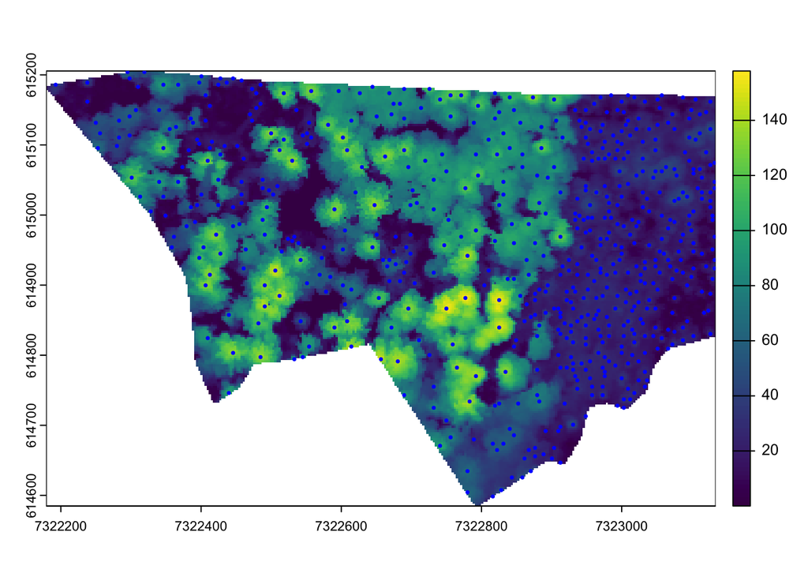

```r
minHeight = 12
# Function for defining dynamic window size
lin <- function(x){x * 0.1 + 1}

# Detect treetops
ttops <- vwf(chm, winFun = lin, minHeight = minHeight)
# Plot CHM
plot(chm, xlab = "", ylab = "", xaxt='n', yaxt = 'n')
# Add dominant treetops to the plot
plot(ttops$geometry, col = "blue", pch = 20, cex = 0.5, add = TRUE)
```

```r
# Create polygon crown map
crowns_poly <- mcws(treetops = ttops, CHM = chm, format = "polygons", minHeight =minHeight)
st_write(ttops, "aoi1_tt.gpkg", delete_dsn = TRUE, quiet = T)
```